# Tutorial

In this tutorial, we illustrate how to use the **fect** package in **R** to implement counterfactual estimators and conduct diagnostic tests proposed by Liu, Wang, and Xu (2022). What start with a simulated dataset.

## Simulated data

**fect** ships two datasets. In this demo, we will primarily be using **simdata**, in which the treatment is allowed to switch on and off. There are 200 units and 35 time periods. We describe its DGP in the [paper](https://papers.ssrn.com/abstract=3555463).

```r
set.seed(1234)
library(fect)
data(fect)
ls()
```

```
#> [1] "simdata"  "simdata1" "turnout"
```

### Visualizing the treatment and outcome variables

Before conducting any statistical analysis, we use the **panelView** package to visualize the treatment and outcome variables in the data. The following line of code plots the treatment status of all units in **simdata**:

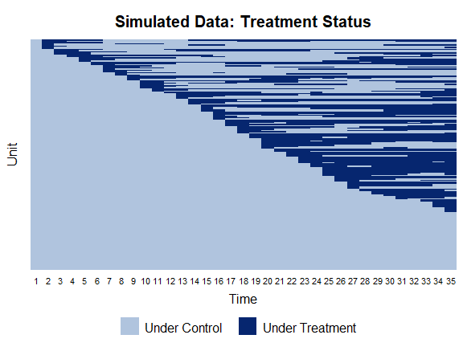

```r
library(panelView)
panelview(Y ~ D, data = simdata, index = c("id","time"),
  axis.lab = "time", xlab = "Time", ylab = "Unit",
  gridOff = TRUE, by.timing = TRUE,
  background = "white", main = "Simulated Data: Treatment Status")
```

We then take a look at the outcome variable. In the figure below, blue and gray represent treatment and control conditions.

```r
panelview(Y ~ D, data = simdata, index = c("id","time"),
  axis.lab = "time", xlab = "Time", ylab = "Unit",
  theme.bw = TRUE, type = "outcome", main = "Simulated Data: Outcome")
```

```
#> Treatment has reversals.
```

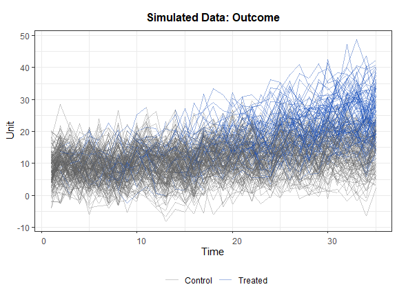

## Counterfactual estimators

In the current version of **fect**, we use three methods to make counterfactual predictions by specifying the `method` option: “fe” (two-way fixed effects, default), “ife” (interactive fixed effects), and “mc” (matrix completion method). First, we illustrate the main syntax of **fect** using the “fe” method.

### Two-way Fixed Effects Coutnerfacutal (FEct)

This estimator is also independently proposed by Borusyak, Jaravel, and Spiess (2021) and Gardner (2021), who refer to it as the “imputation method” and “two-stage DID,” respectively.

**Estimation.** We estimate the average treatment effect on the treated (ATT) using the following information: the outcome variable $Y$, binary treatment variable $D$, two observed covariates $X_{1}$ and $X_{2}$, and the unit and time indicators $id$ and $time$, respectively. The first variable on the right hand side of the formula is the treatment indicator $D$; the rest of the right-hand-side variables serve as controls. The `index` option specifies the unit and time indicators. The `force` option (“none”, “unit”, “time”, and “two-way”) specifies the additive component(s) of the fixed effects included in the model. The default option is “two-way” (including both unit and time fixed effects).

```r
out.fect <- fect(Y ~ D + X1 + X2, data = simdata, index = c("id","time"),
  method = "fe", force = "two-way")
```

**Visualization.** We can use the **plot** function to visualize the estimation results. By default, the **plot** function produces a “gap” plot – as if we type `plot(out.fect, type = "gap")` — which visualizes the estimated period-wise ATT (dynamic treatment effects). For your reference, the true population average effects in **simdata** go from 1 to 3 from the 1st to the 10th post-treatment period.

The bar plot at the bottom of the plot shows the number of treated units for each time period.The options `cex.main`, `cex.lab`, `cex.axis`, and `cex.text` adjust the font sizes of the title, axis labels, axis numbers, and in-graph text, respectively.

Users can choose to plot only those periods whose **number of treated observations** exceeds a threshold, which is set as a proportion of the largest number of treated observations in a period (the default is `proportion = 0.3`).

```
#> Uncertainty estimates not available.
```

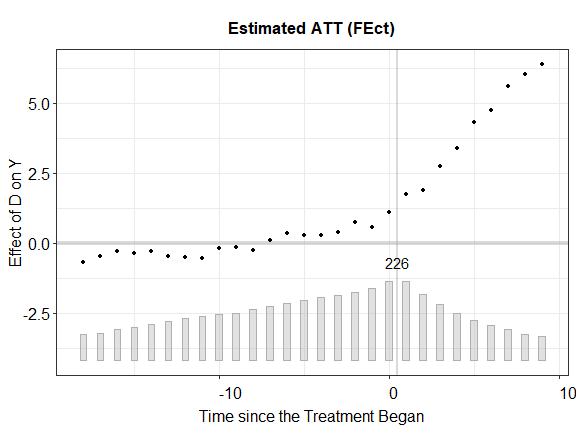

```r
plot(out.fect, main = "Estimated ATT (FEct)", ylab = "Effect of D on Y",
  cex.main = 0.8, cex.lab = 0.8, cex.axis = 0.8)
```

You can then save the graph, a **ggplot2** object, by using the **ggsave** (preferred) function or the **print** function.

**Uncertainty estimates.** The algorithm produces uncertainty estimates when `se = TRUE`. One can use the non-parametric bootstrap procedure by setting `vartype = "bootstrap"`. Note that it only works well when the number of units is relatively large and many experience the treatment condition. The number of bootstrap runs is set by `nboots`.

Alternatively, users can obtain uncertainty estimates using the jackknife method by specifying `vartype = "jackknife"`. The algorithm obtains standard errors by iteratively dropping one unit (the entire time-series) from the dataset.

Parallel computing will speed up both cross-validation and uncertainty estimation significantly. When `parallel = TRUE` (default) and `cores` options are omitted, the algorithm will detect the number of available cores on your computer automatically. (Warning: it may consume most of your computer’s computational power if all cores are being used.)

```r
out.fect <- fect(Y ~ D + X1 + X2, data = simdata, index = c("id","time"),
  method = "fe", force = "two-way", se = TRUE, parallel = TRUE, nboots = 200)
```

The **plot** can then visualize the estimated period-wise ATTs as well as their uncertainty estimates. `stats = "F.p"` shows the p-value for the F test of no-pretrend (more details below).

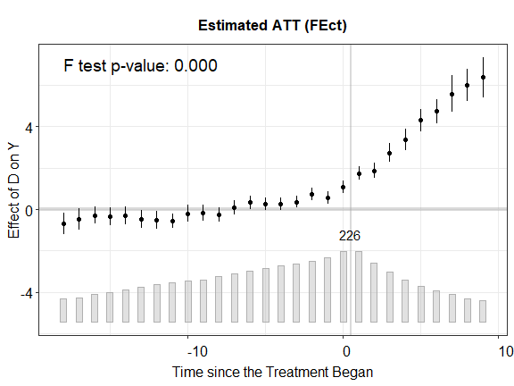

```r
plot(out.fect, main = "Estimated ATT (FEct)", ylab = "Effect of D on Y",
  cex.main = 0.8, cex.lab = 0.8, cex.axis = 0.8, stats = "F.p")
```

**Result summary.** Users can use the **print** function to take a look at a summary of the estimation results or retrieve relevant statistics by directly accessing the fect object. Specifically, `est.avg` and `est.avg.unit` show the ATT averaged over all periods – the former weights each treated observation equally while the latter weights each treated unit equally. `est.beta` reports the coefficients of the time-varying covariates. `est.att` reports the average treatment effect on the treated (ATT) by period. Treatment effect estimates from each bootstrap run is stored in `eff.boot`, an array whose dimension = (#time periods * #treated * #bootstrap runs).

```r
print(out.fect)
```

```
#> Call:
#> fect.formula(formula = Y ~ D + X1 + X2, data = simdata, index = c("id",
#>     "time"), force = "two-way", method = "fe", se = TRUE, nboots = 200,
#>     parallel = TRUE)
#>
#> ATT:
#>                             ATT   S.E. CI.lower CI.upper p.value
#> Tr obs equally weighted   5.121 0.2934    4.546    5.696       0
#> Tr units equally weighted 3.622 0.2468    3.138    4.105       0
#>
#> Covariates:
#>     Coef    S.E. CI.lower CI.upper p.value
#> X1 1.015 0.03218   0.9521    1.078       0
#> X2 2.937 0.03605   2.8663    3.008       0
```

To save space, results are not shown here.

```r
out.fect$est.att
out.fect$est.avg
out.fect$est.beta
```

### The interactive fixed effects counterfactual (IFEct) estimator

In addition to two-way fixed effects, **fect** also supports the interactive fixed effects (IFE) method proposed by Gobillon and Magnac (2016) and Xu (2017) and the matrix completion (MC) method proposed by Athey et al. (2021)—`method = "ife"` and `method = "mc"`, respectively. We use EM algorithm to impute the counterfactuals of treated observations.

For the IFE approach, we need to specify the number of factors using option `r`. For the MC method, we need to specify the tuning parameter in the penalty term using option `lambda`. By default, the algorithm will select an optimal hyper-parameter via a built-in cross-validation procedure.

**Choosing the number of factors.** We provide a cross-validation procedure (by setting `CV = TRUE`) to help determine the tuning parameter in IFE and MC methods. By default, the cross-validation procedure is run for `k` rounds (`k = 10`) and the candidate tuning parameter corresponding to the minimal mean squared prediction error is selected (`criterion = "mspe"`).

In each round, some untreated observations are removed as the testing set to evaluate the prediction ability of the model with a certain tuning parameter. The option `cv.prop` specifies the size of testing set comparing to the set of observations under control (default: `cv.prop = 0.1`). If we want to restrict the testing set to untreated observations only from treated units (those whose treatment statuses have changed), set `cv.treat = TRUE`.

An additional issue is the serial correlation within a unit. We remove a consecutive number of observations from a unit as elements in the testing set in order to avoid over fitting caused by serial correlation. The consecutive number is specified in option `cv.nobs` (e.g. when `cv.nobs = 3`, the test set is a number of triplets).

We can also remove triplets in the fitting procedure but only include the middle observation of each triplet in the test set using the option `cv.donut` (e.g. when `cv.donut = 1`, the first and the last observation in each removed triplet will **not** be included in the test set).

**Hyper-parameter tuning** The package offers several criteria when tuning hyper-parameters. For the IFE method, we can set `criterion = "pc"` to select the hyper-parameter based on the information criterion. If we want to select the hyper-parameter based on mean-squared prediction errors from cross-validation to get a better prediction ability, set `criterion = "mspe"` (default), and to alleviate the impact of some outlier prediction errors, we allow the criterion of geometric-mean squared prediction errors (`criterion = "gmspe"`). If one wants to select the hyper-parameter that yields a better pre-trend fitting on test sets rather than a better prediction ability, set `criterion = "moment"` (we average the residuals in test sets by their relative periods to treatments and then average the squares of these period-wise deviations weighted by the number of observations at each period) .

For the IFE method, we need to specify an interval of candidate number of unobserved factors in option `r` like `r=c(0,5)`. When cross-validation is switched off, the first element in `r` will be set as the number of factors. Below we use the MSPE criterion and search the number of factors from 0 to 5.

```r
out.ife <- fect(Y ~ D + X1 + X2, data = simdata, index = c("id","time"),
          force = "two-way", method = "ife", CV = TRUE, r = c(0, 5),
          se = TRUE, nboots = 200, parallel = TRUE)
```

```
#> Parallel computing ...
#> Cross-validating ...
#> Criterion: Mean Squared Prediction Error
#> Interactive fixed effects model...
#>
#>  r = 0; sigma2 = 6.35460; IC = 2.21891; PC = 6.08178; MSPE = 6.78393
#>
#>  r = 1; sigma2 = 4.52698; IC = 2.24325; PC = 5.26760; MSPE = 4.93004
#>
#>  r = 2; sigma2 = 3.89603; IC = 2.45349; PC = 5.33953; MSPE = 4.50855
#> *
#>
#>  r = 3; sigma2 = 3.79056; IC = 2.78325; PC = 5.98062; MSPE = 5.13365
#>
#>  r = 4; sigma2 = 3.67967; IC = 3.10762; PC = 6.56967; MSPE = 5.72471
#>
#>  r = 5; sigma2 = 3.57625; IC = 3.43005; PC = 7.12886; MSPE = 6.49848
#>
#>
#>  r* = 2
#>
#> Bootstrapping for uncertainties ...
#> 200 runs
```

The figure below shows the estimated ATT using the IFE method. The cross-validation procedure selects the correct number of factors ($r=2$).

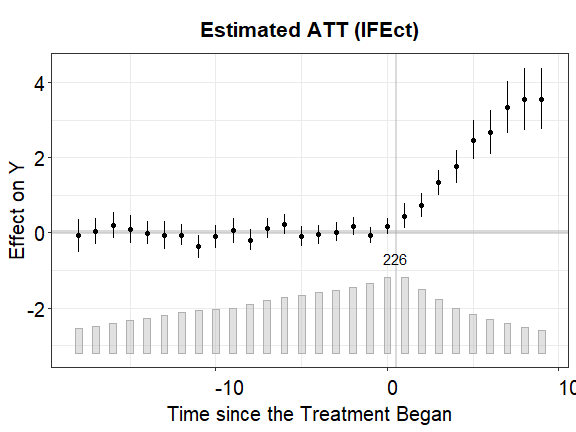

```r
plot(out.ife, main = "Estimated ATT (IFEct)")
```

### The matrix completion (MC) estimator

For the MC method, we also need to specify a sequence of candidate tuning parameters. For example, we can specify `lambda = c(1, 0.8, 0.6, 0.4, 0.2, 0.05)`. If users don’t have any prior knowledge to set candidate tuning parameters, a number of candidate tuning parameters can be generated automatically based on the information from the outcome variable. We specify the number in option `nlambda`, e.g. `nlambda = 10`.

```r
out.mc <- fect(Y ~ D + X1 + X2, data = simdata, index = c("id","time"),
          force = "two-way", method = "mc", CV = TRUE,
          se = TRUE, nboots = 200, parallel = TRUE)
```

```
#> Parallel computing ...
#> Cross-validating ...
#> Criterion: Mean Squared Prediction Error
#> Matrix completion method...
#>
#>  lambda.norm = 1.00000; MSPE = 7.02065; MSPTATT = 0.28561; MSE = 5.80999
#>
#>  lambda.norm = 0.42170; MSPE = 5.45943; MSPTATT = 0.12218; MSE = 4.15356
#>
#>  lambda.norm = 0.17783; MSPE = 5.17432; MSPTATT = 0.04007; MSE = 1.57548
#> *
#>
#>  lambda.norm = 0.07499; MSPE = 5.37711; MSPTATT = 0.00815; MSE = 0.28590
#>
#>  lambda.norm = 0.03162; MSPE = 5.63317; MSPTATT = 0.00170; MSE = 0.05133
#>
#>  lambda.norm = 0.01334; MSPE = 6.55505; MSPTATT = 0.00034; MSE = 0.00914
#>
#>
#>  lambda.norm* = 0.177827941003892
#>
#> Bootstrapping for uncertainties ...
#> 200 runs
```

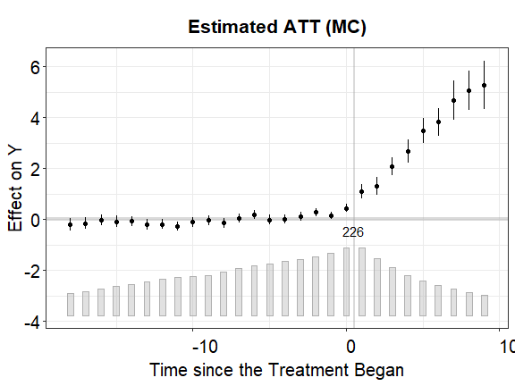

```r
plot(out.mc, main = "Estimated ATT (MC)")
```

### Balanced sample

The package **fect** provides the option balance.period which allows the calculation of the average treatment effects only for units that exhibit complete data in specified pre- and post-treatment periods. For instance, if the option is set to `balance.period = c(-3,4)`, the program will calculate the average treatment effects for units that have at least four consecutive non-missing observations in the pre-treatment periods (-3, -2, -1, 0) and at least four consecutive non-missing observations in the post-treatment periods (1, 2, 3, 4).

```r
out.bal <- fect(Y ~ D + X1 + X2, data = simdata, index = c("id","time"),
  balance.period = c(-3, 4), force = "two-way", method = "ife",
  CV = FALSE, r = 2, se = TRUE, nboots = 200, parallel = TRUE)
```

```
#> Parallel computing ...
#> Bootstrapping for uncertainties ...
#> 200 runs
```

We can then visualize the dynamic treatment effects using the inbuilt function **plot**. By default, it displays the dynamic treatment effects of the “balanced” sample.

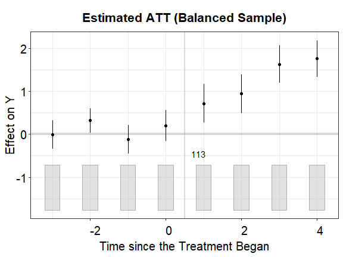

```r
plot(out.bal, main = "Estimated ATT (Balanced Sample)")
```

### Weighted Treatment Effect

The package offers the option `W` to calculate the weighted average treatment effects. The weighting variable does not affect the estimation of fixed effects or factors. Only the weighted average treatment effects or weighted dynamic treatment effects are obtained by aggregating the treatment effects using the weight `W`.

```r
simdata$Weight <- abs(rnorm(n = dim(simdata)[1]))
out.w <- fect(Y ~ D + X1 + X2, data = simdata, index = c("id","time"),
  force = "two-way", method = "ife", W = 'Weight',
  CV = FALSE, r = 2, se = TRUE, nboots = 200, parallel = TRUE)
```

```
#> Parallel computing ...
#> Bootstrapping for uncertainties ...
#> 200 runs
```

We can then visualize the weighted dynamic treatment effects using the inbuilt function **plot**, it by default shows the weighted dynamic treatment effects.

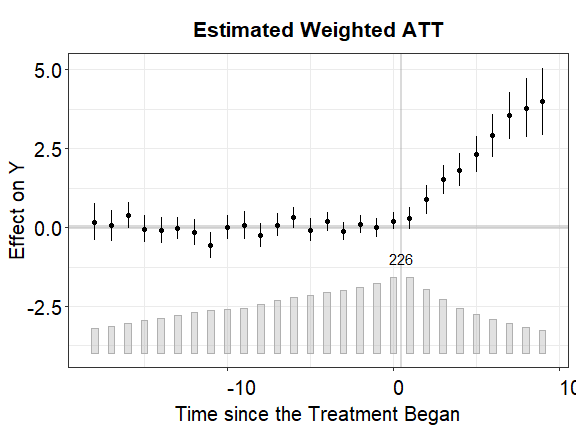

```r
plot(out.w, main = "Estimated Weighted ATT")
```

## Heterogeneous treatment effects

We provide several methods for researchers to explore heterogeneous treatment effects (HTE).

### Box plots

One way to understand HTE is to use a series of box plots to visualize the estimated individualistic treatment effects of observations under the treatment condition (by setting `type = "box"`). Although these effects are not identified at the individual observation level, their level of dispersion is informative of treatment effects heterogeneity at different (relative) time periods, as well as model performance.

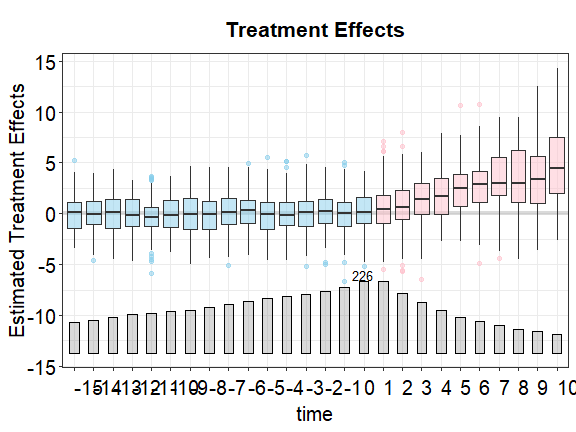

```r
plot(out.ife, type = "box", xlim = c(-15, 10))
```

### By calendar time

Another way to explore HTE is to investigate how the treatment effect evolves over time. In the plot below, the point estimates represents the ATTs by calendar time; the blue curve and band represent a lowess fit of the estimates and its 95% confidence interval, respectively; and the red horizontal dashed line represents the ATT (averaged over all time periods).

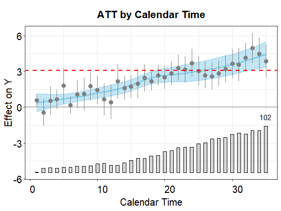

```r
plot(out.ife, type = "calendar", xlim = c(1, 35))
```

## Diagostic tests

We provide three types of diagnostic tests: (1) a placebo test, (2) a test for (no) pretrend, and (3) a test for (no) carry-over effects. For each test, we support both the difference-in-means (DIM) approach and the equivalence approach. The details are provided in the paper.

### Placebo tests

We provide a placebo test for a settled model—hence, cross-validation is not allowed—by setting `placeboTest = TRUE`. We specify a range of pretreatment periods as “placebo periods” in option `placebo.period` to remove observations in the specified range for model fitting, and then test whether the estimated ATT in this range is significantly different from zero. Below, we set `c(-2, 0)` as the placebo periods.

```r
out.fect.p <- fect(Y ~ D + X1 + X2, data = simdata, index = c("id", "time"),
  force = "two-way", parallel = TRUE, se = TRUE, CV = 0,
  nboots = 200, placeboTest = TRUE, placebo.period = c(-2, 0))

out.ife.p <- fect(Y ~ D + X1 + X2, data = simdata, index = c("id", "time"),
  force = "two-way", method = "ife",  r = 2, CV = 0,
  parallel = TRUE, se = TRUE,
  nboots = 200, placeboTest = TRUE, placebo.period = c(-2, 0))

out.mc.p <- fect(Y ~ D + X1 + X2, data = simdata, index = c("id", "time"),
  force = "two-way", method = "mc",  lambda = out.mc$lambda.cv,
  CV = 0, parallel = TRUE, se = TRUE,
  nboots = 200, placeboTest = TRUE, placebo.period = c(-2, 0))
```

The placebo test conducts two types of tests:

**t test.** If t-test p-value is smaller than a pre-specified threshold (e.g. 5%), we reject the null of no-differences. Hence, the placebo test is deemed failed.

**TOST.** The TOST checks whether the 90% confidence intervals for estimated ATTs in the placebo period exceed a pre-specified range (defined by a threshold), or the equivalence range. A TOST p-value smaller than a pre-specified threshold suggests that the null of difference bigger than the threshold is rejected; hence, the placebo test is passed.

By default, the plot will display the p-value of the $t$-test (`stats = "placebo.p"`). Users can also add the p-value of a corresponding TOST test by setting `stats = c("placebo.p","equiv.p")`. A larger placebo p-value from a t-test and a smaller placebo TOST p-value are preferred.

Users can turn off the dotted plot in placebo periods by setting `vis = "none"`.

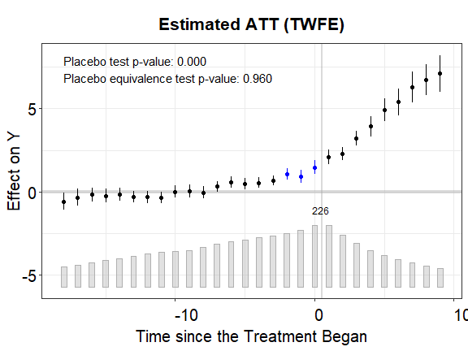

```r
plot(out.fect.p, cex.text = 0.8, stats = c("placebo.p","equiv.p"),
     main = "Estimated ATT (TWFE)")
```

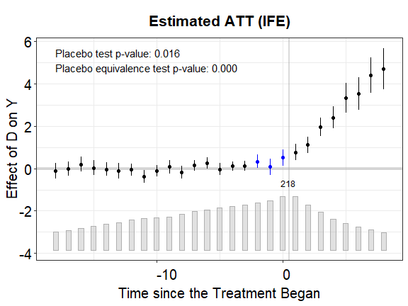

```r
plot(out.ife.p, ylab = "Effect of D on Y", main = "Estimated ATT (IFE)",
     cex.text = 0.8, stats = c("placebo.p","equiv.p"))
```

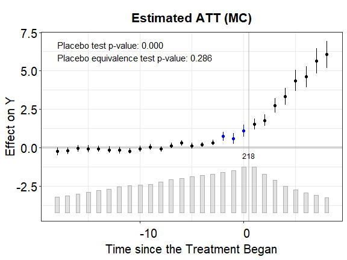

```r
plot(out.mc.p, vis = "none", cex.text = 0.8, stats = c("placebo.p","equiv.p"),
     main = "Estimated ATT (MC)")
```

The results in the placebo test confirm that IFEct is a better model than MC for this particular DGP.

### Tests for (no) pre-trend

We introduce two statistical tests for the presence of a pre-trend (or the lack thereof). The first test is an $F$ test for zero residual averages in the pretreatment periods. The second test is a two-one-sided $t$ (TOST) test, a type of equivalence tests.

**F test.** We offer a goodness-of-fit test (a variant of the $F$ test) and to gauge the presence of pretreatment (differential) trends. A larger F-test p-value suggests a better pre-trend fitting. Users can specify a test range in option `pre.periods`. For example, `pre.periods = c(-4,0)` means that we test pretreatment trend of the last 5 periods prior to the treatment (from period -4 to period 0). If `pre.period = NULL` (default), all pretreatment periods in which the number of treated units exceeds the total number of treated units * `proportion` will be included in the test.

**TOST.** The TOST checks whether the 90% confidence intervals for estimated ATTs in the pretreatment periods (again, subject to the `proportion` option) exceed a pre-specified range, or the equivalence range. A smaller TOST p-value suggests a better pre-trend fitting. While users can check the values of confidence intervals, we give a visualization of the equivalence test. We can plot the pretreatment residual average with the equivalence confidence intervals by setting `type = "equiv"`. Option `tost.threshold` sets the equivalence range (the default is $0.36\sigma_{\epsilon}$ in which $\sigma_{\epsilon}$ is the standard deviation of the outcome variable after two-way fixed effects are partialed out). By setting `range = "both"`, both the minimum range (in gray) and the equivalence range (in red) are drawn.

On the topleft corner of the graph, we show several statistics of the user’s choice. User can choose which statistics to show by setting `stats = c("none", "F.stat", "F.p", "F.equiv.p", "equiv.p")` which corresponds to not showing any, the $F$ statistic, the p-value for the $F$ test, the p-value for the equivalence $F$ test, the (maximum) p-value for the the TOST tests, respectively. For the gap plot, the default is `stats = "none"`. For the equivalence plot, the default is `stats = c("equiv.p, F.p")`. Users can also change the labels of statistics using the `stats.labs` options. Users can adjust its position using the `stats.pos` option, for example `stats.pos = c(-30, 4)`. To turn off the statistics, set `stats = "none"`.

Below, we visualize the result of the equivalence test for each of the three estimators using our simulated data. These figures show that both the IFE and MC methods pass the equivalence test while the FE method does not.

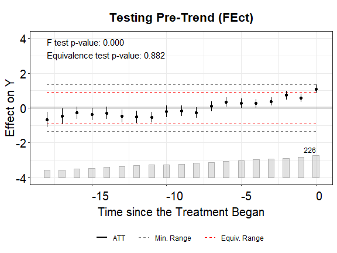

```r
plot(out.fect, type = "equiv", ylim = c(-4,4),
     cex.legend = 0.6, main = "Testing Pre-Trend (FEct)", cex.text = 0.8)
```

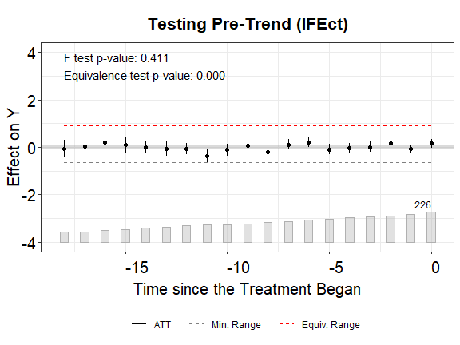

```r
plot(out.ife, type = "equiv", ylim = c(-4,4),
     cex.legend = 0.6, main = "Testing Pre-Trend (IFEct)", cex.text = 0.8)
```

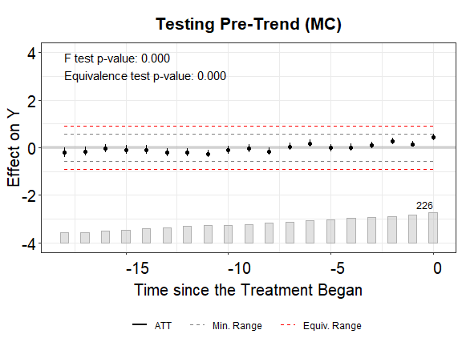

```r
plot(out.mc, type = "equiv", ylim = c(-4,4),
     cex.legend = 0.6, main = "Testing Pre-Trend (MC)", cex.text = 0.8)
```

From the above plots, we see that FEct fails both tests; IFEct passes both tests using a conventional test size (5%); and MC fails the F tests, but passes the TOST (equivalence) test. Hence, we may conclude that IFEct is a more suitable model.

#### Leave-one-out pre-trend test

Instead of using estimated ATTs for periods prior to the treatment to test for pre-trends, we can use a leave-one-out (LOO) approach (`loo = TRUE`) to consecutively hide one pretreatment period (relative to the timing of the treatment) and repeatedly estimate the pseudo treatment effects for that pretreatment period. The LOO approach can be understood as an extension of the placebo test. It has the benefit of providing users with a more holistic view of whether the identifying assumptions likely hold. However, as the program needs to conduct uncertainty estimates for each turn, it is much more time-consuming than the original one.

```r
out.fect.loo <- fect(Y ~ D + X1 + X2, data = simdata, index = c("id","time"),
  method = "fe", force = "two-way", se = TRUE, parallel = TRUE, nboots = 200, loo = TRUE)
out.ife.loo <- fect(Y ~ D + X1 + X2, data = simdata, index = c("id","time"),
  method = "ife", force = "two-way", se = TRUE, parallel = TRUE, nboots = 200, loo = TRUE)
out.mc.loo <- fect(Y ~ D + X1 + X2, data = simdata, index = c("id","time"),
  method = "mc", force = "two-way", se = TRUE, parallel = TRUE, nboots = 200, loo = TRUE)
```

After the LOO estimation, one can plot these LOO pre-trends in the gap plot or the equivalence plot by setting `loo = TRUE` in the **plot** function.

```r
plot(out.fect.loo, type = "equiv", ylim = c(-4,4), loo = TRUE,
     cex.legend = 0.6, main = "Testing Pre-Trend LOO (FEct)", cex.text = 0.8)

plot(out.ife.loo, type = "equiv", ylim = c(-4,4), loo = TRUE,
     cex.legend = 0.6, main = "Testing Pre-Trend LOO (IFEct)", cex.text = 0.8)

plot(out.mc.loo, type = "equiv", ylim = c(-4,4), loo = TRUE,
     cex.legend = 0.6, main = "Testing Pre-Trend LOO (MC)", cex.text = 0.8)
```

[output not shown]

### Exiting the treatment

**fect** allows the treatment to switch back and forth and provides diagnostic tools for this setting. After the estimation, we can visualize the period-wise ATTs relative to the **exit** of treatments by setting `type = "exit"` (one can still draw the classic gap plot by setting `type = "gap"`). The x-axis is then realigned based on the timing of the treatment’s exit, not onset, e.g., 1 represents 1 period after the treatment ends.

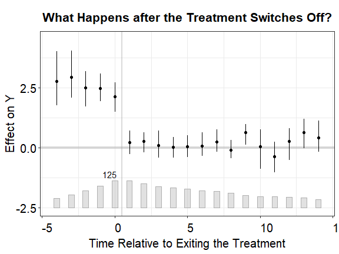

```r
plot(out.fect, type = "exit", ylim = c(-2.5,4.5), main = "What Happens after the Treatment Switches Off?")
```

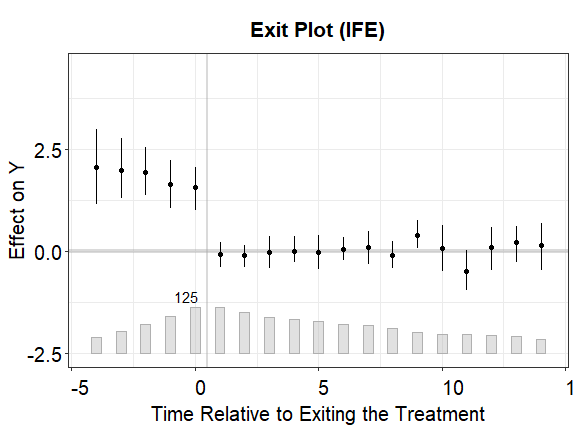

```r
plot(out.ife, type = "exit", ylim = c(-2.5,4.5), main = "Exit Plot (IFE)")
```

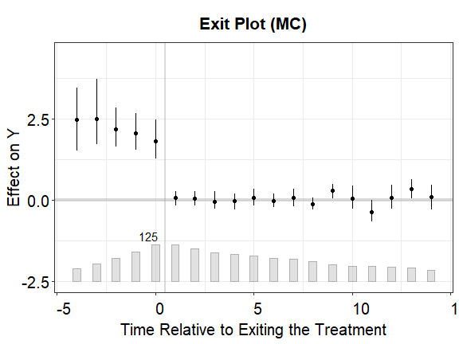

```r
plot(out.mc, type = "exit", ylim = c(-2.5,4.5), main = "Exit Plot (MC)")
```

### Tests for (no) carryover effects

The idea of the placebo test can be extended to testing the presence of carryover effects. Instead of hiding a few periods right before the treatment starts, we hide a few periods right after the treatment ends. If carryover effects do not exist, we would expect the average prediction error in those periods to be close to zero. To perform the carryover test, we set the option `carryoverTest = TRUE`. We can treat a range of exit-treatment periods in option `carryover.period` to remove observations in the specified range for model fitting, and then test whether the estimated ATT in this range is significantly different from zero.

Below, we set `carryover.period = c(1, 3)`. As we deduct the treatment effect from the outcome in **simdata**, we expect the average prediction error for these removed periods to be close to zero.

```r
out.fect.c <- fect(Y ~ D + X1 + X2, data = simdata, index = c("id", "time"),
  force = "two-way", parallel = TRUE, se = TRUE, CV = 0,
  nboots = 200, carryoverTest = TRUE, carryover.period = c(1, 3))

out.ife.c <- fect(Y ~ D + X1 + X2, data = simdata, index = c("id", "time"),
  force = "two-way", method = "ife", r = 2, CV = 0,
  parallel = TRUE, se = TRUE,
  nboots = 200, carryoverTest = TRUE, carryover.period = c(1, 3))

out.mc.c <- fect(Y ~ D + X1 + X2, data = simdata, index = c("id", "time"),
  force = "two-way", method = "mc",  lambda = out.mc$lambda.cv,
  CV = 0, parallel = TRUE, se = TRUE,
  nboots = 200, carryoverTest = TRUE, carryover.period = c(1, 3))
```

Like the placebo test, the plot will display the p-value of the carryover effect test (`stats = "carryover.p"`). Users can also add the p-value of a corresponding TOST test by setting `stats = c("carryover.p","equiv.p")`.

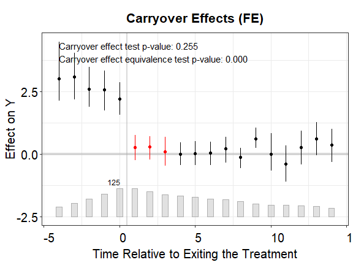

```r
plot(out.fect.c, type = "exit", ylim = c(-2.5,4.5),
          cex.text = 0.8, main = "Carryover Effects (FE)")
```

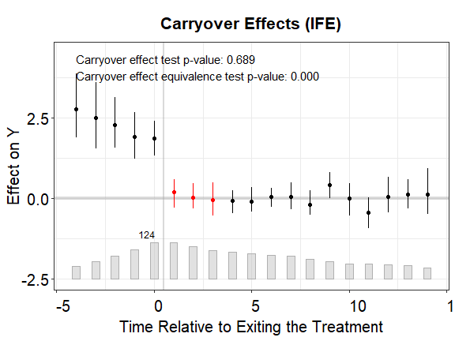

```r
plot(out.ife.c, type = "exit", ylim = c(-2.5,4.5),
          cex.text = 0.8, main = "Carryover Effects (IFE)")
```

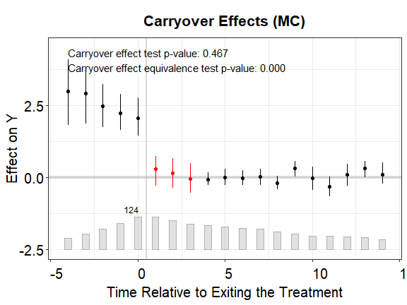

```r
plot(out.mc.c, type = "exit", ylim = c(-2.5,4.5),
          cex.text = 0.8, main = "Carryover Effects (MC)")
```

Once again, the IFE estimator outperforms the other two.

Using real-world data, researchers will likely find that carryover effects exist. If such effects are limited, researchers can consider removing a few periods after the treatment ended for the treated units from the first-stage estimation (using the `carryover.period` option) and re-estimated the model (and re-conduct the test). We provide such an example in the paper. Here, we illustrate the option using **simdata**.

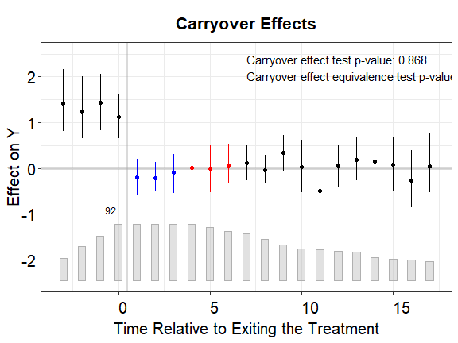

```r
out.ife.rm.test <- fect(Y ~ D + X1 + X2, data = simdata, index = c("id", "time"),
  force = "two-way", method = "ife", r = 2, CV = 0,
  parallel = TRUE, se = TRUE,  carryover.rm = 3,
  nboots = 200, carryoverTest = TRUE, carryover.period = c(1, 3))# remove three periods

plot(out.ife.rm.test, cex.text = 0.8, stats.pos = c(7, 2.5))
```

In the above plot, the three periods in blue are droppred from the first-stage estimation of the factor model while the periods in red are reserved for the (no) carryover effects test.

## Other options

We provide a few other options for estimation and visualization.

### More visualization options

The **plot()** function shipped in **fect** offers some options that help to improve the visualization.

We can remove the bar plot at the bottom of the plot by setting `count = FALSE`

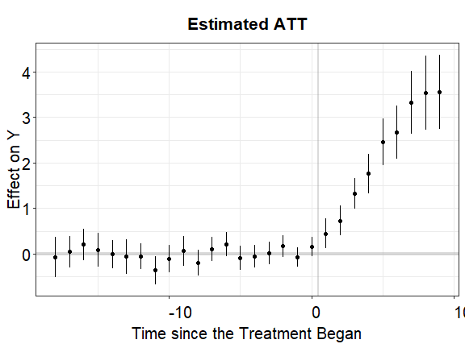

```r
plot(out.ife, count = FALSE)
```

By setting the option `show.points = TRUE`, we visualize the estimated period-wise ATTs as well as their uncertainty estimates in point-wise vertical intervals. The shorter interval at each point corresponds to the 90% confidence interval of ATT while the longer interval corresponds to the 95% confidence interval.

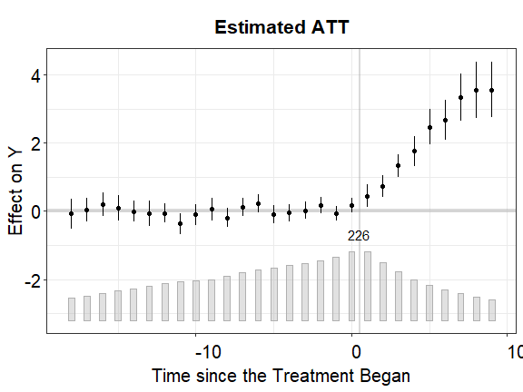

```r
plot(out.ife, show.points = TRUE)
```

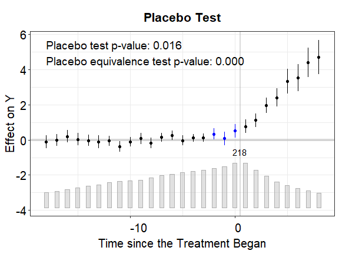

```r
plot(out.ife.p, show.points = TRUE)
```

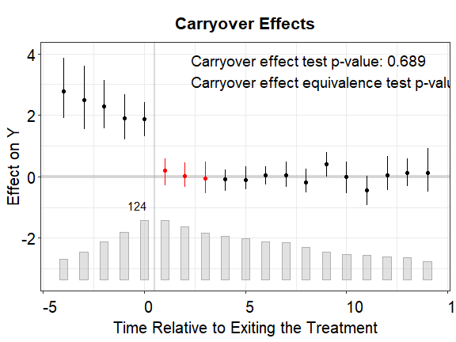

```r
plot(out.ife.c, type = "exit", show.points = TRUE, stats.pos = c(2.3,4))
```

By setting the option `type = "status"`, we can visualize the treatment status of all observations. We only present the label of the time by setting `axis.lab = "time"`.

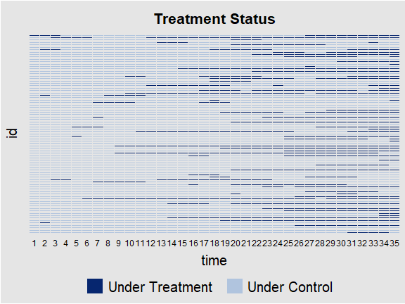

```r
plot(out.fect, type = 'status', axis.lab = "time", cex.axis  = 0.6)
```

For the placebo test, the manually hided observations are marked in cyan. We can show only a sub-group’s treatment status by specifying the option `id` to certain units.

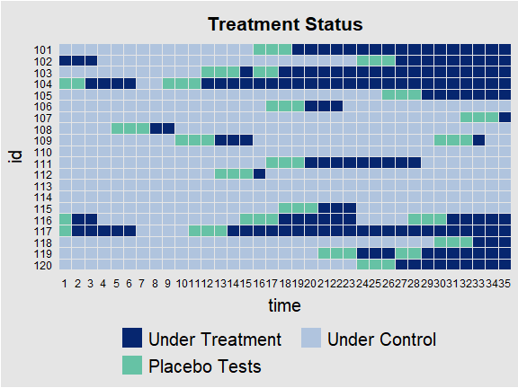

```r
plot(out.fect.p, type = 'status', axis.lab = "both", id = c(101:120), cex.axis  = 0.6)
```

For the carryover test, the manually hidden observations are marked in light red. We can also move grid lines by setting `gridOff = TRUE`.

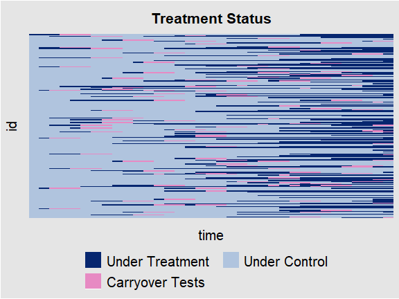

```r
plot(out.fect.c, type = 'status', axis.lab = "off", gridOff = TRUE)
```

For the carryover test with removed observation, the removed observations are marked in yellow.

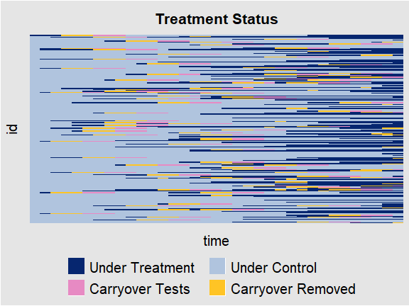

```r
plot(out.ife.rm.test, type = 'status', axis.lab = "off", gridOff = TRUE)
```